Two awesome things inspired this post:

- [`{ggplot2}`’s version 3.0 release](https://www.tidyverse.org/articles/2018/07/ggplot2-3-0-0/) on [CRAN](https://cran.r-project.org/), including full support for the `{sf}` package and new functions `geom_sf()` and `coord_sf()`, which make plotting data from shapefiles very straightforward.
- [Jonas Scholey’s blog post](http://jschoeley.github.io/2018/06/30/bubble-grid-map.html) discussing the use of “bubble grid” maps as an alternative to [chlorepath](https://en.wikipedia.org/wiki/Choropleth_map) maps, which seem to be used more prevalent.

As Jonas implies, using color as a visual encoding is not always the best option, a notion with which I strongly agree. [Cartograms](https://en.wikipedia.org/wiki/Cartogram) try to address the ambiguity of color encoding with distortion of land area/distance, but I think the result can be difficult to interpret. Bubble grid maps seem to me to be an interesting alternative that can potentially display information in a more direct manner.

With that being said, I decided to adapt Jonas’ code to visualize the Texas high school SAT/ACT data that I’ve looked at in other posts. To simplify the visual encoding of information, I’ll filter the data down to a single statistic—the math test scores for the SAT for the year 2015. (For other applications, the statistic might be population density, average median household income, etc.) For the geo-spatial data, I downloaded the shapefiles for [schools](https://schoolsdata2-tea-texas.opendata.arcgis.com/datasets/059432fd0dcb4a208974c235e837c94f_0) and [counties](https://schoolsdata2-tea-texas.opendata.arcgis.com/datasets/c71146b6426248a5a484d8b3c192b9fe_0) provided by the [Texas Education Agency](https://tea.texas.gov/) (TEA). Additionally, I downloaded a shapefile for [Texas highways](http://hub.arcgis.com/datasets/e661b4004aee4c939569a563b6bb881a_0), provided by the [Texas Department of Transportation](https://www.txdot.gov/) (TxDOT). By plotting the major roadways in the state, the locations of “sparsely” populated areas should be evident, which can explain why there doesn’t appear to any data in some regions. Finally, I’ll also use the Texas state and county border data provided in the `ggplot2::map_data()` (which is essentially just serves as a wrapper for extracting data provided in the `{maps}` package).

```r
library("tidyverse")
library("teplot")
library("sf")
```

I’ll skip over the data collection and cleaning steps and show the “final” data.frames that I’m using.

```r
schools_tea_filt
```

```
## # A tibble: 1,567 x 12
##    test   year school  district county city  value reading writing english
##    <chr> <int> <chr>   <chr>    <chr>  <chr> <dbl>   <dbl> <chr>     <dbl>
##  1 SAT    2015 A C JO~ BEEVILL~ BEE    CORP~   458     465 452          NA
##  2 SAT    2015 A M CO~ COLLEGE~ BRAZOS HUNT~   567     542 510          NA
##  3 SAT    2015 A MACE~ DALLAS ~ DALLAS RICH~   411     387 394          NA
##  4 SAT    2015 A+ ACA~ A+ ACAD~ DALLAS RICH~   428     383 383          NA
##  5 SAT    2015 ABBOTT~ ABBOTT ~ HILL   WACO    539     527 489          NA
##  6 SAT    2015 ABERNA~ ABERNAT~ HALE   LUBB~   533     463 483          NA
##  7 SAT    2015 ABILENE ABILENE~ TAYLOR ABIL~   482     466 443          NA
##  8 SAT    2015 ACADEMY ACADEMY~ BELL   WACO    538     512 500          NA
##  9 SAT    2015 ACADEM~ ABILENE~ TAYLOR ABIL~   507     510 462          NA
## 10 SAT    2015 ACADEM~ ACADEMY~ BEXAR  SAN ~   428     445 400          NA
## # ... with 1,557 more rows, and 2 more variables: science <dbl>,
## #   total <dbl>
```

```r
schools_sf
```

```
## # A tibble: 8,701 x 11
##     schl_nm school  distrct  city  county regn_nm grd_grp  grd_gr_ instr_t
##       <int> <fct>   <fct>    <fct> <fct>    <int> <fct>      <int> <fct>
##  1  2.090e7 HOOD-C~ ALVIN I~ ALVIN BRAZO~       4 EE PK K~       1 REGULA~
##  2  5.891e7 KLONDI~ KLONDIK~ LAME~ DAWSON      17 EE PK K~       5 REGULA~
##  3  1.591e7 SOMERS~ SOMERSE~ SOME~ BEXAR       20 09 10 1~       4 REGULA~
##  4  1.592e7 HOWSMA~ NORTHSI~ SAN ~ BEXAR       20 EE PK K~       1 REGULA~
##  5  1.019e8 WARNER~ CYPRESS~ CYPR~ HARRIS       4 KG 01 0~       1 REGULA~
##  6  1.019e8 WOODCR~ HUMBLE ~ HOUS~ HARRIS       4 06 07 08       2 REGULA~
##  7  1.179e8 SANFOR~ SANFORD~ FRIT~ HUTCH~      16 09 10 1~       4 REGULA~
##  8  6.191e7 ARGYLE  ARGYLE ~ ARGY~ DENTON      11 09 10 1~       4 REGULA~
##  9  2.209e8 BIRDVI~ BIRDVIL~ NORT~ TARRA~      11 09 10 1~       4 REGULA~
## 10  1.019e8 DR DEB~ CYPRESS~ KATY  HARRIS       4 EE PK K~       1 REGULA~
## # ... with 8,691 more rows, and 2 more variables: magnet <fct>,
## #   geometry <POINT [Â°]>
```

```r
schools_sf
```

[output not shown]

```r
hwys_sf
```

```
## # A tibble: 225 x 15
##       fid rte_nm   rte_prfx rte_nbr rdbd_type begin_dfo end_dfo asset_nm
##     <dbl> <fct>    <fct>      <dbl> <fct>         <dbl>   <dbl> <fct>
##  1  1.000 SH0155-~ SH        155    KG            78.75  123    Memorial ~
##  2  8.000 US0190-~ US        190    KG           308     340    Memorial ~
##  3  9.000 SH0155-~ SH        155    KG            41.64   55.02 Memorial ~
##  4 14.00  IH0014-~ IH         14.00 KG           283     302    Memorial ~
##  5 15.00  SH0155-~ SH        155    KG            55.88   68.43 Memorial ~
##  6 19.00  US0190-~ US        190    KG           255     277    Memorial ~
##  7 20.00  SH0155-~ SH        155    KG             0      40.15 Memorial ~
##  8 22.00  FM0510-~ FM        510    KG            20.33   22.24 Memorial ~
##  9 25.00  IH0014-~ IH         14.00 KG           277     282    Memorial ~
## 10 26.00  US0077-~ US         77.00 KG           428     518    Memorial ~
## # ... with 215 more rows, and 7 more variables: memorial_h <fct>,
## #   asset_cmnt <fct>, des_type <fct>, system <fct>, shape_len <dbl>,
## #   n <int>, geometry <LINESTRING [Â°]>
```

```r
tx_border
```

```
## # A tibble: 1,088 x 6
##      long   lat group order region subregion
##  *  <dbl> <dbl> <dbl> <int> <chr>  <chr>
##  1 -94.50 33.67 50.00 12203 texas  <NA>
##  2 -94.48 33.66 50.00 12204 texas  <NA>
##  3 -94.48 33.63 50.00 12205 texas  <NA>
##  4 -94.46 33.62 50.00 12206 texas  <NA>
##  5 -94.45 33.60 50.00 12207 texas  <NA>
##  6 -94.42 33.60 50.00 12208 texas  <NA>
##  7 -94.41 33.58 50.00 12209 texas  <NA>
##  8 -94.40 33.57 50.00 12210 texas  <NA>
##  9 -94.37 33.58 50.00 12211 texas  <NA>
## 10 -94.31 33.57 50.00 12212 texas  <NA>
## # ... with 1,078 more rows
```

Here I create the grid of data that I’ll use for the visual. (Thanks to Jonas for [his example](http://jschoeley.github.io/2018/06/30/bubble-grid-map.html).)

```r
counties_grid_sf <-
  counties_sf %>%
  st_make_grid(n = c(50, 50))

schools_grid_sf <-
  counties_sf %>%
  left_join(schools_tea_filt) %>%
  select(value) %>%
  st_interpolate_aw(to = counties_grid_sf, extensive = TRUE) %>%
  st_centroid() %>%
  cbind(st_coordinates(.))
```

```r
schools_grid_sf
```

```
## # A tibble: 1,280 x 5
##    Group_1   value      X     Y       geometry
##      <dbl>   <dbl>  <dbl> <dbl>   <POINT [Â°]>
##  1   33.00   NA    -98.11 25.94 (-98.11 25.94)
##  2   34.00   53.61 -97.84 25.94 (-97.84 25.94)
##  3   35.00  835    -97.58 25.94 (-97.58 25.94)
##  4   36.00 1197    -97.32 25.94 (-97.32 25.94)
##  5   37.00  254    -97.06 25.94 (-97.06 25.94)
##  6   81.00   NA    -98.63 26.16 (-98.63 26.16)
##  7   82.00   NA    -98.37 26.16 (-98.37 26.16)
##  8   83.00   NA    -98.11 26.16 (-98.11 26.16)
##  9   84.00   NA    -97.84 26.16 (-97.84 26.16)
## 10   85.00 1833    -97.58 26.16 (-97.58 26.16)
## # ... with 1,270 more rows
```

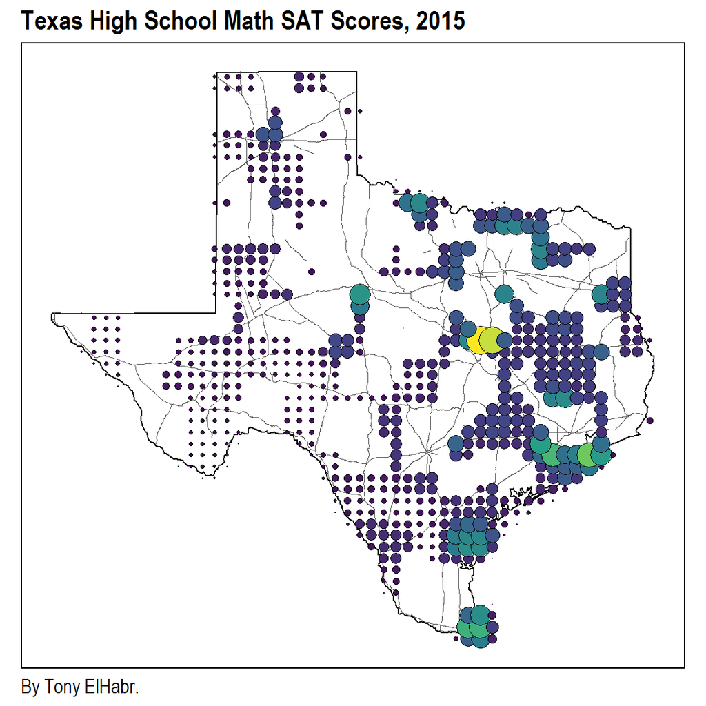

```r
viz_schools_grid <-
  schools_grid_sf %>%
  ggplot() +
  geom_polygon(
    data = tx_border,
    ggplot2::aes(x = long, y = lat, group = group),
    color = "black",
    fill = NA
  ) +
  geom_sf(
    data = hwys_sf,
    linetype = "solid",
    size = 0.1,
    fill = "gray90"
  ) +
  coord_sf(datum = NA) +
  geom_point(
    aes(x = X, y = Y, size = value, fill = value),
    shape = 21,
    color = "black",
    show.legend = FALSE
  ) +
  scale_size_area(max_size = 8) +
  scale_fill_viridis_c() +
  teplot::theme_map() +
  labs(
    title = str_wrap("Texas High School Math SAT Scores, 2015", 80),
    caption = "By Tony ElHabr."
  )
viz_schools_grid
```